# Create a Document Term/Feature Matrix

In deze documentatie gaan we bekijken hoe we efficiënter een Document Term Matrix (DTM) en een Document Feature Matrix (DFM) kunnen creëren.

## **DTM**

### DTM Sequentieel

Voor een DTM te creëren maken we gebruiken van het tm-package, en hebben we als input een corpus die ook is opgebouwd met de tm-package.

```r
createDTM <- function() {

  dtm_ctrl <- list(
    tokenize = "words",
    tolower = FALSE,
    removePunctuation = FALSE,
    removeNumbers = FALSE,
    stopwords = FALSE,
    stemming = FALSE,
    dictionary = NULL,
    bounds = list(global = c(1, Inf)),
    weighting = weightTf,
    wordLengths = c(1, Inf)
  )
  print("dtm_raw")
  dtm_raw <- DocumentTermMatrix(docsCorpus, control = dtm_ctrl)
  #save(dtm_raw, dtm_ctrl, file = "dtm_raw.RDa")
  return(dtm_raw)
}
```

### DTM Parallel

Bovenstaande code hebben we geparallelliseerd, door behulp van onze corpus op te delen in chunks met onderstaande code.

```r
createCorpusChunks <- function(no_chunks){

  corpusLenght <- length(docsCorpus)
  return(foreach(i=1:no_chunks ) %do% {
            og <- round((i -1) * corpusLenght / no_chunks) + 1
            bg <- round(corpusLenght / no_chunks * i)
            print(paste0(og," ---> ",bg))
            docsCorpus[og:bg]
          })

}
```

Hier gaan we op basis van de lengte van onze corpus chunks aanmaken zoals te zien in *createCorpusChunks*. We verdelen de corpus op basis van het argument dat we met de functie zullen meegeven. Deze zal het aantal cores representeren.

```r
createDTMChunked <- function() {

  dtm_ctrl <- list(
    tokenize = "words",
    tolower = FALSE,
    removePunctuation = FALSE,
    removeNumbers = FALSE,
    stopwords = FALSE,
    stemming = FALSE,
    dictionary = NULL,
    bounds = list(global = c(1, Inf)),
    weighting = weightTf,
    wordLengths = c(1, Inf)
  )
  chunks <- createCorpusChunks(no_chunks = no_cores)
  cluster <- makeCluster(no_cores,outfile="")
  registerDoParallel(cluster)
  dtmList <-
    foreach(chunk = chunks,
            .packages = "tm") %dopar% {
              DocumentTermMatrix(chunk,control=dtm_ctrl)
            }
  stopCluster(cluster)
  dtm <- do.call(tm:::c.DocumentTermMatrix,dtmList)
  return(dtm)
}
```

## **DFM**

### DFM Sequentieel

Onderstaande code toont de creatie van een Document-Feature Matrix, deze kan enkel gecreërd worden op een corpus van *Quanteda*. Doordat onze cleaning op de Quanteda Corpus streng geweest kan zijn gaan we hier kijken of er zich geen zero rows bevinden => Rijen met enkel nullen in. Deze gaan we dan verwijderen voor verdere problemen te voorkomen. Cosine clustering zal een fout geven als er zero rows zouden zijn in de DFM, doordat deze geen cosine bewerking kan doen op een zero vector.

```r
createDFMnormal <- function() {
  dtm_raw <- dfm(docsCorpusQuan)
  rowSums(dtm_raw, na.rm = FALSE)
    tryCatch(
    {
      print("try1")
      dtm_raw <- dtm_raw[rowSums(dtm_raw[,-1]) != 0,]
      print("try")
      return(dtm_raw)
    },
    error = function(condition) {
    print("catch")
    return(dtm_raw)
    }
  )
  return(dtm_raw)
}
```

### DFM naar DTM

Onze DFM kan ook omgezet worden naar een DTM voor moest dit handig zijn. Zo kunnen er ook functies van de tm-package op de originele DFM uitgevoerd worden.

```r
createDFMasDTM <- function() {
  dtm_raw <- dfm(docsCorpusQuan)
  tryCatch(
    {
      print("try1")
      dtm_raw <- dtm_raw[rowSums(dtm_raw[,-1]) != 0,]
      print("try")
      return(dtm_raw)
    },
    error = function(condition) {
    print("catch")
    return(dtm_raw)
    }
  )
  dtm_raw <- convert(dtm_raw, to = "tm")
  return(dtm_raw)
}
```

### DFM Parallel in chunks

```r
makeCreateDFMCluster <- function() {
  cl <- makeCluster(no_cores, outfile = "")
  clusterEvalQ(cl, { library("quanteda") })
  return(cl)
}
```

Voor de DFM parallel te creëren gaan we onze corpus opsplitsen in chunks. Dit gaan we doen aan de hand van het aantal rijen in onze doc, die we dan gaan onderverdelen in dezelfde hoeveelheid chunks als dat we cores hebben.

deze subsets gaan we bijhouden in een list, die we achteraf pas gaan samenvoegen. Dit is niet de beste manier om te doen, hier kom ik later op terug.

rbind op een DFM zal dus de document ID’s gaan samenvoegen op rijen, het voordeel bij DFM is dat als er reeds een bepaalde *feature* in de kolommen staat, dat deze er niet nog is bijgezet zal worden. Hij gaat enkel nieuwe *features* toevoegen als kolommen.

```r
createDFMChunks <- function() {
  cl <- makeCreateDFMCluster()
  no_cores <- detectCores()
  registerDoParallel(cl)
  dfmList <- list()
  docrows <- nrow(docs)
  dc <- docsCorpusQuan
  dfmList <-
    foreach(i = 1:no_cores) %dopar% {
      og <- round((i - 1) * docrows / no_cores) + 1
      print(paste(no_cores, docrows))
      bg <- round(docrows / no_cores * i)
      print(paste(og, bg))
      sub <- tokens_subset(dc, id >= og & id <= bg)
      dfm(sub)
    }

  stopCluster(cl)
  dfmTotal <- dfmList[[1]]

  for (i in 2:length(dfmList)) {
    dfmTotal <- rbind(dfmTotal, dfmList[[i]])
  }
  dfmList <- dfmList[rowSums(dfmList[,-1]) != 0,]

  return(dfmTotal)
}
```

Zoals hierboven besproken is achteraf alles binden niet de beste methode. Dit is ontzettend traag. Als we rbind meteen meegeven in de foreach zal dit al veel sneller verlopen. Hierdoor moeten we geen extra lijst bijhouden. DFM blijft hetzelfde werken zoals hierboven uitgelegd.

```r
createDFMChunksBind <- function() {
  cl <- makeCreateDFMCluster()
  # no_cores <- detectCores() - 1
  registerDoParallel(cl)
  dfmList <- list()
  docrows <- nrow(docsCorpusQuan)
  dc <- docsCorpusQuan
  dfmList <-
    foreach(i = 1:no_cores*2, .combine = rbind, .export = "no_cores") %dopar% {
      og <- round((i - 1) * docrows / no_cores) + 1
      print(paste(no_cores, docrows))
      bg <- round(docrows / no_cores * i)
      print(paste(og, bg))
      sub <- tokens_subset(dc, id >= og & id <= bg)
      dfm(sub)
    }

  stopCluster(cl)
  tryCatch(
    {
      print("try1")
      dfmList <- dfmList[rowSums(dfmList[,-1]) != 0,]
      print("try")
      return(dfmList)
    },
    error = function(condition) {
      print("catch")
      return(dfmList)
    }
  )
}
```

## 50.000

```r
readRDS("./resources/benchmark50k.rds")
```

```
Unit: milliseconds
```

| expr | min | lq | mean | median | uq | max | neval |
| --- | --- | --- | --- | --- | --- | --- | --- |
| createDFMnormal() | 584.3716 | 584.3716 | 584.3716 | 584.3716 | 584.3716 | 584.3716 | 1 |
| createDFMasDTM() | 610.4150 | 610.4150 | 610.4150 | 610.4150 | 610.4150 | 610.4150 | 1 |
| createDFMChunksBind() | 4680.5024 | 4680.5024 | 4680.5024 | 4680.5024 | 4680.5024 | 4680.5024 | 1 |
| createDTM() | 12702.3173 | 12702.3173 | 12702.3173 | 12702.3173 | 12702.3173 | 12702.3173 | 1 |
| createDTMChunked() | 5543.6326 | 5543.6326 | 5543.6326 | 5543.6326 | 5543.6326 | 5543.6326 | 1 |

## 500.000

```r
readRDS("./resources/benchmark500k.rds")
```

```
Unit: seconds
```

| expr | min | lq | mean | median | uq | max | neval |
| --- | --- | --- | --- | --- | --- | --- | --- |
| createDFMnormal() | 5.066707 | 5.066707 | 5.066707 | 5.066707 | 5.066707 | 5.066707 | 1 |
| createDFMasDTM() | 4.465060 | 4.465060 | 4.465060 | 4.465060 | 4.465060 | 4.465060 | 1 |
| createDFMChunksBind() | 17.527205 | 17.527205 | 17.527205 | 17.527205 | 17.527205 | 17.527205 | 1 |
| createDTM() | 121.483035 | 121.483035 | 121.483035 | 121.483035 | 121.483035 | 121.483035 | 1 |
| createDTMChunked() | 42.218099 | 42.218099 | 42.218099 | 42.218099 | 42.218099 | 42.218099 | 1 |

## 1.500.000

```r
readRDS("./resources/benchmark1.5m.rds")
```

```
Unit: seconds
```

| expr | min | lq | mean | median | uq | max | neval |
| --- | --- | --- | --- | --- | --- | --- | --- |
| createDFMnormal() | 18.99331 | 18.99331 | 18.99331 | 18.99331 | 18.99331 | 18.99331 | 1 |
| createDFMasDTM() | 22.19566 | 22.19566 | 22.19566 | 22.19566 | 22.19566 | 22.19566 | 1 |
| createDFMChunksBind() | 46.84742 | 46.84742 | 46.84742 | 46.84742 | 46.84742 | 46.84742 | 1 |
| createDTMChunked() | 153.86065 | 153.86065 | 153.86065 | 153.86065 | 153.86065 | 153.86065 | 1 |

## 3.200.000

```r
readRDS("./resources/benchmark3.2m.rds")
```

```
Unit: seconds
```

| expr | min | lq | mean | median | uq | max | neval |
| --- | --- | --- | --- | --- | --- | --- | --- |
| createDFMnormal() | 51.41715 | 51.41715 | 51.41715 | 51.41715 | 51.41715 | 51.41715 | 1 |
| createDFMasDTM() | 51.06568 | 51.06568 | 51.06568 | 51.06568 | 51.06568 | 51.06568 | 1 |
| createDFMChunksBind() | 99.43980 | 99.43980 | 99.43980 | 99.43980 | 99.43980 | 99.43980 | 1 |

## 4.800.000

```r
readRDS("./resources/benchmark4.8m.rds")
```

```
Unit: seconds
```

| expr | min | lq | mean | median | uq | max | neval |
| --- | --- | --- | --- | --- | --- | --- | --- |
| createDFMnormal() | 79.58672 | 79.58672 | 79.58672 | 79.58672 | 79.58672 | 79.58672 | 1 |
| createDFMasDTM() | 75.30377 | 75.30377 | 75.30377 | 75.30377 | 75.30377 | 75.30377 | 1 |
| createDFMChunksBind() | 142.76549 | 142.76549 | 142.76549 | 142.76549 | 142.76549 | 142.76549 | 1 |

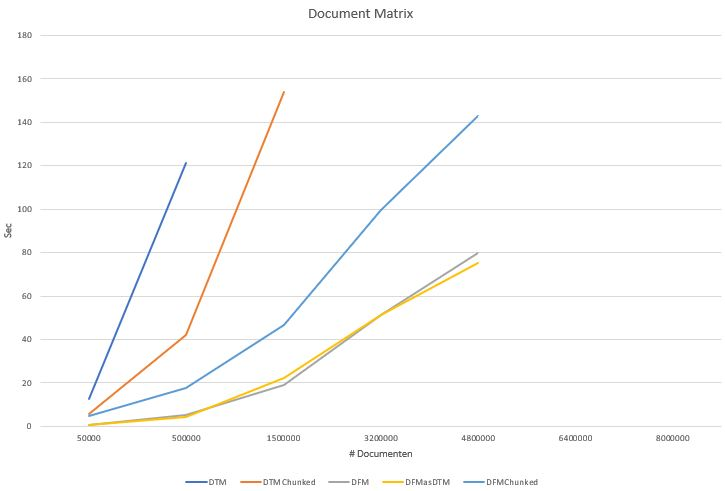

[ **Fig. 1:** *DTM en DFM technieken in functie van tijd en grootte van dataset*]